# Projet fin d’année

Drissi Jehan & Sdiri Dorsaf

28 avril 2016

## Resumé :

Nous disposons d’un jeu de données de 8 biscuits 4 fabriqués en Pakistan et 4 en France. Une evaluation sensorielle a été organisée pour caractèriser ce produit. Un jury de 12 experts (entrainé) a evalué chacun de ces produits lors de 2 seances de dégustation et sur une liste de 23 descripteurs sensoriels. Les notes varient entre 0 et 10. 0:extremement faible et 10:extremement fort.

## Exploration des données

```r
data=read.table(file=file.choose(),header=T,sep=";",dec=".")
head(data)
```

```
##   seance juge produit Vcouleur Vépaisseur Ooeuf Olait Obeurre Ovanille
## 1      1    1      F4        9         10     4     4      10        0
## 2      1    1      F2       10          3     0     6       5        6
## 3      1    1      P3        6          3     4     3       2       10
## 4      1    1      F3        2         10     3     3       0        0
## 5      1    1      P4        9          4     0     1       8        0
## 6      1    1      F1        7          3     4     2       7        8
##   Ocaramel Ocitron Tdurcroq Tfriabilité Tgranusabl Tfarineux Tcraqcroust
## 1        2       0        5           7          9         0           4
## 2        5       0        5           1          1         7           9
## 3        8       0        9           1          7         2          10
## 4        0       0        7           7          3         6           2
## 5        0       5        2           8          0         8           1
## 6        8       1        9           7          3         7           8
##   Tpâteux Tfondant Gsalé Gsucré Goeuf Glait Gbeurre Gvanille Gcaramel
## 1      10        8     6      5     3     4       9        0        2
## 2       9        1     2      3     0     3       4        2        5
## 3       5        0     1      8     6     4       6       10        8
## 4       1        8     7      3     0     4       1        3        0
## 5       6        9     4      3     3     5       8        1        3
## 6       8        3     5      4     1     3       9        7        7
##   Gcitron
## 1       0
## 2       0
## 3       2
## 4       0
## 5       5
## 6       1
```

```r
dim(data)
```

```
## [1] 192  26
```

```r
data$seance=as.factor(data$seance)
data$juge=as.factor(data$juge)
str(data)
```

```
## 'data.frame':    192 obs. of  26 variables:
##  $ seance     : Factor w/ 2 levels "1","2": 1 1 1 1 1 1 1 1 1 1 ...
##  $ juge       : Factor w/ 12 levels "1","2","3","4",..: 1 1 1 1 1 1 1 1 2 2 ...
##  $ produit    : Factor w/ 8 levels "F1","F2","F3",..: 4 2 7 3 8 1 6 5 4 2 ...
##  $ Vcouleur   : int  9 10 6 2 9 7 7 3 5 9 ...
##  $ Vépaisseur : int  10 3 3 10 4 3 6 2 9 2 ...
##  $ Ooeuf      : int  4 0 4 3 0 4 0 6 2 1 ...
##  $ Olait      : int  4 6 3 3 1 2 0 3 3 4 ...
##  $ Obeurre    : int  10 5 2 0 8 7 0 6 8 3 ...
##  $ Ovanille   : int  0 6 10 0 0 8 4 4 1 9 ...
##  $ Ocaramel   : int  2 5 8 0 0 8 1 0 1 9 ...
##  $ Ocitron    : int  0 0 0 0 5 1 8 0 1 0 ...
##  $ Tdurcroq   : int  5 5 9 7 2 9 5 7 8 8 ...
##  $ Tfriabilité: int  7 1 1 7 8 7 8 3 8 2 ...
##  $ Tgranusabl : int  9 1 7 3 0 3 4 1 8 4 ...
##  $ Tfarineux  : int  0 7 2 6 8 7 8 2 5 8 ...
##  $ Tcraqcroust: int  4 9 10 2 1 8 3 9 5 10 ...
##  $ Tpâteux    : int  10 9 5 1 6 8 2 2 2 7 ...
##  $ Tfondant   : int  8 1 0 8 9 3 1 6 6 8 ...
##  $ Gsalé      : int  6 2 1 7 4 5 3 4 8 4 ...
##  $ Gsucré     : int  5 3 8 3 3 4 6 4 7 5 ...
##  $ Goeuf      : int  3 0 6 0 3 1 0 8 3 1 ...
##  $ Glait      : int  4 3 4 4 5 3 0 7 2 4 ...
##  $ Gbeurre    : int  9 4 6 1 8 9 4 6 8 3 ...
##  $ Gvanille   : int  0 2 10 3 1 7 4 3 1 5 ...
##  $ Gcaramel   : int  2 5 8 0 3 7 1 3 1 7 ...
##  $ Gcitron    : int  0 0 2 0 5 1 8 0 0 0 ...
```

```r
summary(data)
```

```
##  seance      juge       produit      Vcouleur        Vépaisseur
##  1:96   1      :16   F1     :24   Min.   : 0.000   Min.   : 1.000
##  2:96   2      :16   F2     :24   1st Qu.: 4.000   1st Qu.: 3.000
##         3      :16   F3     :24   Median : 6.000   Median : 5.000
##         4      :16   F4     :24   Mean   : 5.781   Mean   : 5.526
##         5      :16   P1     :24   3rd Qu.: 8.000   3rd Qu.: 8.000
##         6      :16   P2     :24   Max.   :10.000   Max.   :10.000
##         (Other):96   (Other):48
##      Ooeuf           Olait           Obeurre          Ovanille
##  Min.   :0.000   Min.   : 0.000   Min.   : 0.000   Min.   : 0.000
##  1st Qu.:1.000   1st Qu.: 1.000   1st Qu.: 3.000   1st Qu.: 0.000
##  Median :3.000   Median : 3.000   Median : 5.000   Median : 4.000
##  Mean   :3.219   Mean   : 3.665   Mean   : 5.063   Mean   : 3.745
##  3rd Qu.:6.000   3rd Qu.: 6.000   3rd Qu.: 8.000   3rd Qu.: 7.000
##  Max.   :9.000   Max.   :10.000   Max.   :10.000   Max.   :10.000
##                  NA's   :1        NA's   :1
##     Ocaramel       Ocitron          Tdurcroq       Tfriabilité
##  Min.   :0.00   Min.   : 0.000   Min.   : 0.000   Min.   : 0.000
##  1st Qu.:0.00   1st Qu.: 0.000   1st Qu.: 4.000   1st Qu.: 2.000
##  Median :2.00   Median : 0.000   Median : 5.000   Median : 5.000
##  Mean   :2.88   Mean   : 1.188   Mean   : 5.547   Mean   : 4.896
##  3rd Qu.:5.00   3rd Qu.: 1.000   3rd Qu.: 7.000   3rd Qu.: 7.000
##  Max.   :9.00   Max.   :10.000   Max.   :10.000   Max.   :10.000
##
##    Tgranusabl       Tfarineux       Tcraqcroust      Tpâteux
##  Min.   : 0.000   Min.   : 0.000   Min.   : 0.0   Min.   : 0.000
##  1st Qu.: 3.000   1st Qu.: 3.000   1st Qu.: 3.0   1st Qu.: 3.000
##  Median : 7.000   Median : 6.000   Median : 6.0   Median : 5.000
##  Mean   : 5.825   Mean   : 5.458   Mean   : 5.5   Mean   : 4.984
##  3rd Qu.: 8.000   3rd Qu.: 8.000   3rd Qu.: 8.0   3rd Qu.: 7.000
##  Max.   :10.000   Max.   :10.000   Max.   :10.0   Max.   :10.000
##  NA's   :3
##     Tfondant          Gsalé            Gsucré           Goeuf
##  Min.   : 0.000   Min.   : 0.000   Min.   : 0.000   Min.   :0.000
##  1st Qu.: 3.000   1st Qu.: 2.000   1st Qu.: 4.000   1st Qu.:1.000
##  Median : 5.000   Median : 4.000   Median : 6.000   Median :2.000
##  Mean   : 5.048   Mean   : 3.844   Mean   : 5.719   Mean   :2.728
##  3rd Qu.: 7.000   3rd Qu.: 6.000   3rd Qu.: 7.000   3rd Qu.:4.000
##  Max.   :10.000   Max.   :10.000   Max.   :10.000   Max.   :9.000
##  NA's   :3                                          NA's   :1
##      Glait           Gbeurre          Gvanille         Gcaramel
##  Min.   : 0.000   Min.   : 0.000   Min.   : 0.000   Min.   : 0.000
##  1st Qu.: 1.000   1st Qu.: 4.000   1st Qu.: 0.000   1st Qu.: 0.000
##  Median : 4.000   Median : 6.000   Median : 3.000   Median : 2.000
##  Mean   : 3.686   Mean   : 5.516   Mean   : 3.326   Mean   : 2.644
##  3rd Qu.: 6.000   3rd Qu.: 8.000   3rd Qu.: 6.000   3rd Qu.: 4.500
##  Max.   :10.000   Max.   :10.000   Max.   :10.000   Max.   :10.000
##  NA's   :1        NA's   :2        NA's   :2        NA's   :1
##     Gcitron
##  Min.   : 0.000
##  1st Qu.: 0.000
##  Median : 0.000
##  Mean   : 1.068
##  3rd Qu.: 0.000
##  Max.   :10.000
##
```

```r
attach(data)
```

## statistique descriptive:

## *Les variables quantitative:*

#### Mode:

C’est valeur correspondant a l’effectif le plus elevÃ©

```r
names(which.max(table(Ocitron)))
```

```
## [1] "0"
```

```r
names(which.max(table(Gcitron)))
```

```
## [1] "0"
```

```r
names(which.max(table(Tcraqcroust)))
```

```
## [1] "8"
```

```r
names(which.max(table(Obeurre)))
```

```
## [1] "5"
```

#### Median:

C’est la valeur qui devise la pop en 2 sous-echantillons égaux

```r
median(Olait,na.rm=T)
```

```
## [1] 3
```

```r
median(Vcouleur,na.rm=T)
```

```
## [1] 6
```

```r
median(Gsucré,na.rm=T)
```

```
## [1] 6
```

```r
median(Gsalé,na.rm=T)
```

```
## [1] 4
```

#### La variance:

C’est une mesure servant à caractÃ©riser la dispersion d’un échantillon

```r
var(Gcitron,na.rm=T)
```

```
## [1] 6.335706
```

```r
var(Tgranusabl,na.rm=T)
```

```
## [1] 7.857649
```

```r
var(Vcouleur,na.rm=T)
```

```
## [1] 6.517343
```

```r
var(Gsalé,na.rm=T)
```

```
## [1] 7.053992
```

#### L’ecart type:

C’est dèfinit la moyenne quadratique des Ã©carts par rapport à la moyenne

```r
sd(Olait,na.rm=T)
```

```
## [1] 2.875079
```

```r
sd(Ocitron,na.rm=T)
```

```
## [1] 2.549253
```

```r
sd(Vépaisseur,na.rm=T)
```

```
## [1] 2.614769
```

```r
sd(Gbeurre,na.rm=T)
```

```
## [1] 2.809143
```

## *Les variables qualitative:*

```r
library(knitr)
library(sjPlot)
data2=data[c(1:3)]
```

seance

| value | N | raw % | valid % | cumulative % |
| --- | --- | --- | --- | --- |
| 1 | 96 | 50.00 | 50.00 | 50.00 |
| 2 | 96 | 50.00 | 50.00 | 100.00 |
| missings | 0 | 0.00 |  |  |
| total N=192 · valid N=192 · x̄=1.50 · σ=0.50 |  |  |  |  |

juge

| value | N | raw % | valid % | cumulative % |
| --- | --- | --- | --- | --- |
| 1 | 16 | 8.33 | 8.33 | 8.33 |
| 2 | 16 | 8.33 | 8.33 | 16.67 |
| 3 | 16 | 8.33 | 8.33 | 25.00 |
| 4 | 16 | 8.33 | 8.33 | 33.33 |
| 5 | 16 | 8.33 | 8.33 | 41.67 |
| 6 | 16 | 8.33 | 8.33 | 50.00 |
| 7 | 16 | 8.33 | 8.33 | 58.33 |
| 8 | 16 | 8.33 | 8.33 | 66.67 |
| 9 | 16 | 8.33 | 8.33 | 75.00 |
| 10 | 16 | 8.33 | 8.33 | 83.33 |
| 11 | 16 | 8.33 | 8.33 | 91.67 |
| 12 | 16 | 8.33 | 8.33 | 100.00 |
| missings | 0 | 0.00 |  |  |
| total N=192 · valid N=192 · x̄=6.50 · σ=3.46 |  |  |  |  |

produit

| value | N | raw % | valid % | cumulative % |
| --- | --- | --- | --- | --- |
| F1 | 24 | 12.50 | 12.50 | 12.50 |
| F2 | 24 | 12.50 | 12.50 | 25.00 |
| F3 | 24 | 12.50 | 12.50 | 37.50 |
| F4 | 24 | 12.50 | 12.50 | 50.00 |
| P1 | 24 | 12.50 | 12.50 | 62.50 |
| P2 | 24 | 12.50 | 12.50 | 75.00 |
| P3 | 24 | 12.50 | 12.50 | 87.50 |
| P4 | 24 | 12.50 | 12.50 | 100.00 |
| missings | 0 | 0.00 |  |  |
| total N=192 · valid N=192 · x̄=4.50 · σ=2.30 |  |  |  |  |

## Intérpretation des données :

### Effet seance:

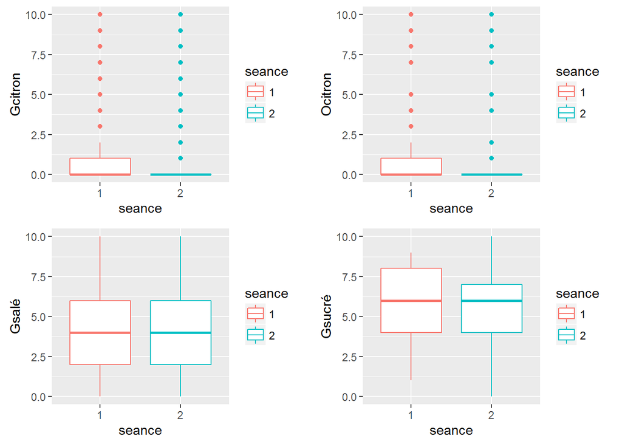

```r
library(ggplot2)
library(gridExtra)
t1=ggplot(data=data,aes(seance, Gcitron,colour=seance))+geom_boxplot()
t2=ggplot(data=data,aes(seance,Ocitron,colour=seance))+geom_boxplot()
t3=ggplot(data=data,aes(seance,Gsalé,colour=seance))+geom_boxplot()
t4=ggplot(data=data,aes(seance,Gsucré,colour=seance))+geom_boxplot()
arrange_plot=grid.arrange(t1,t2,t3,t4,nrow=2)
```

– On remarque une difference non significative , repetabilité des juges d’une séance à l’autre **pas d’effet seance**

### Effet Produit :

#### *comparaison des notes de chaque produit pour les produits Pakistanais:*

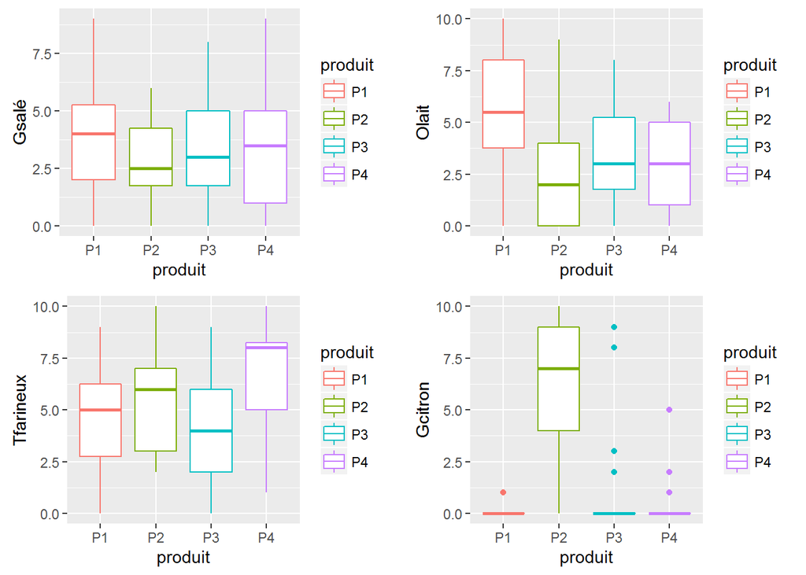

```r
library(ggplot2)
data.=na.omit(data)
data_p1=subset(data,data$produit=="P1")
data_p2=subset(data,data$produit=="P2")
data_p3=subset(data,data$produit=="P3")
data_p4=subset(data,data$produit=="P4")
library(abind)
data_pakis=rbind(data_p1,data_p2,data_p3,data_p4)
attach(data_pakis)

p1=ggplot(data=data_pakis,aes(produit,Gsalé,colour=produit))+geom_boxplot()
p2=ggplot(data=data_pakis,aes(produit,Olait,colour=produit))+geom_boxplot()
p3=ggplot(data=data_pakis,aes(produit,Tfarineux,colour=produit))+geom_boxplot()
p4=ggplot(data=data_pakis,aes(produit,Gcitron,colour=produit))+geom_boxplot()
library(gridExtra)
arrange_plot=grid.arrange(p1,p2,p3,p4,nrow=2)
```

#### *comparaison des notes de chaque produit pour les produits francais :*

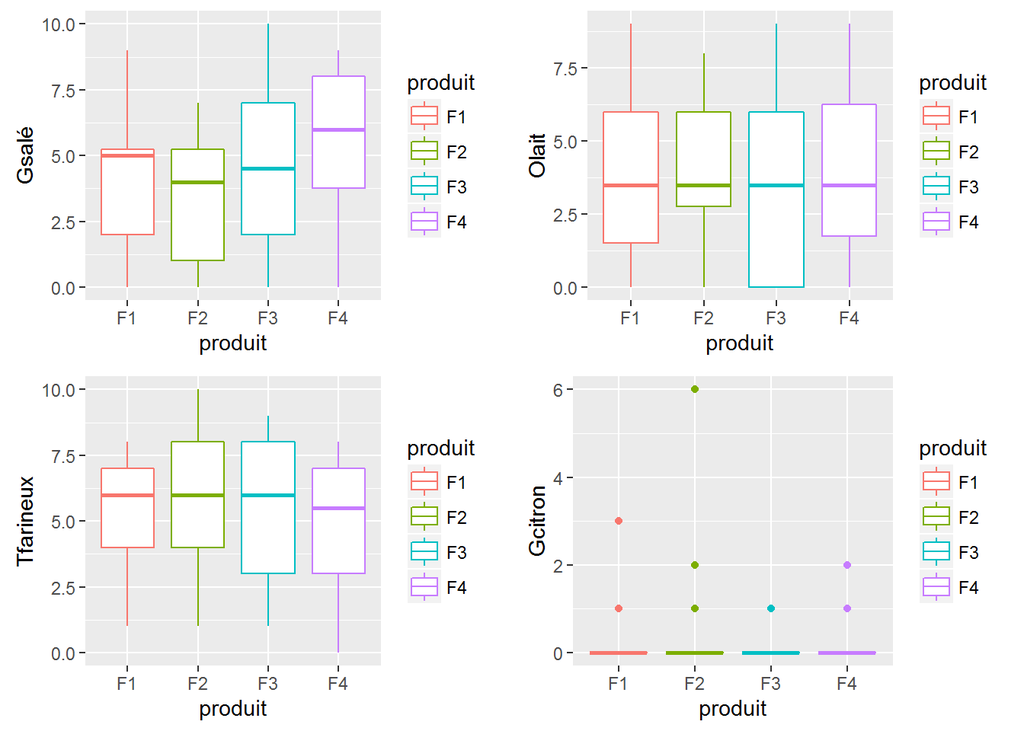

```r
library(ggplot2)
data.=na.omit(data)
data_f1=subset(data,data$produit=="F1")
data_f2=subset(data,data$produit=="F2")
data_f3=subset(data,data$produit=="F3")
data_f4=subset(data,data$produit=="F4")
library(abind)
data_fr=rbind(data_f1,data_f2,data_f3,data_f4)
attach(data_fr)

f1=ggplot(data=data_fr,aes(produit,Gsalé,colour=produit))+geom_boxplot()
f2=ggplot(data=data_fr,aes(produit,Olait,colour=produit))+geom_boxplot()
f3=ggplot(data=data_fr,aes(produit,Tfarineux,colour=produit))+geom_boxplot()
f4=ggplot(data=data_fr,aes(produit,Gcitron,colour=produit))+geom_boxplot()
library(gridExtra)
arrange_plot=grid.arrange(f1,f2,f3,f4,nrow=2)
```

*Conclusion : les produits français se rassemblent beaucoup mais les produits pakistanais montrent une différence significative*

### Effet juge :

#### *comparaison des notes de chaque juge pour les produits pakistanais:*

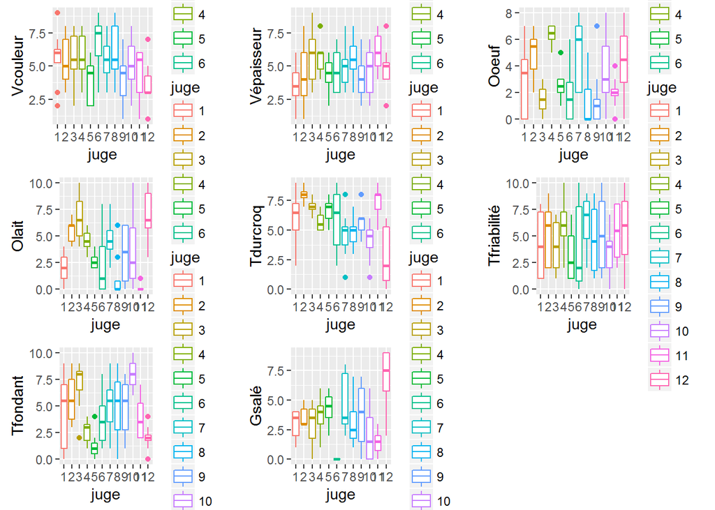

```r
j1=ggplot(data_pakis,aes(x=juge,y=Vcouleur,colour=juge))+geom_boxplot()
j2=ggplot(data_pakis,aes(x=juge,y=Vépaisseur,colour=juge))+geom_boxplot()
j3=ggplot(data_pakis,aes(x=juge,y=Ooeuf,colour=juge))+geom_boxplot()
j4=ggplot(data_pakis,aes(x=juge,y=Olait,colour=juge))+geom_boxplot()
j5=ggplot(data_pakis,aes(x=juge,y=Tdurcroq,colour=juge))+geom_boxplot()
j6=ggplot(data_pakis,aes(x=juge,y=Tfriabilité,colour=juge))+geom_boxplot()
j7=ggplot(data_pakis,aes(x=juge,y=Tfondant,colour=juge))+geom_boxplot()
j8=ggplot(data_pakis,aes(x=juge,y=Gsalé,colour=juge))+geom_boxplot()

grid.arrange(j1,j2,j3,j4,j5,j6,j7,j8)
```

#### *comparaison des notes de chaque juge pour les produits francais:*

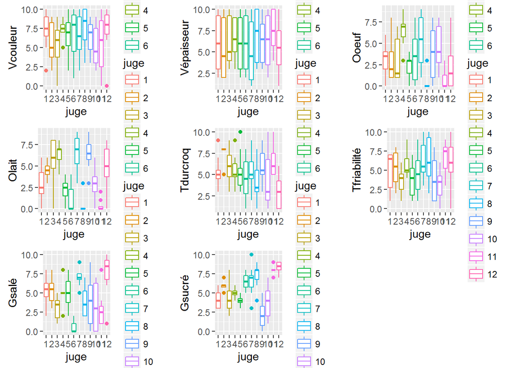

```r
library(ggplot2)
library(gridExtra)
g1=ggplot(data_fr,aes(x=juge,y=Vcouleur,colour=juge))+geom_boxplot()
g2=ggplot(data_fr,aes(x=juge,y=Vépaisseur,colour=juge))+geom_boxplot()
g3=ggplot(data_fr,aes(x=juge,y=Ooeuf,colour=juge))+geom_boxplot()
g4=ggplot(data_fr,aes(x=juge,y=Olait,colour=juge))+geom_boxplot()
g5=ggplot(data_fr,aes(x=juge,y=Tdurcroq,colour=juge))+geom_boxplot()
g6=ggplot(data_fr,aes(x=juge,y=Tfriabilité,colour=juge))+geom_boxplot()
g7=ggplot(data_fr,aes(x=juge,y=Gsalé,colour=juge))+geom_boxplot()
g8=ggplot(data_fr,aes(x=juge,y=Gsucré,colour=juge))+geom_boxplot()

grid.arrange(g1,g2,g3,g4,g5,g6,g7,g8)
```

— on remarque une diffèrence remarquable des notes données par chaque juge pour les diffèrents descripteurs.

## Analyse en composantes principales:

### *Effet coude:*

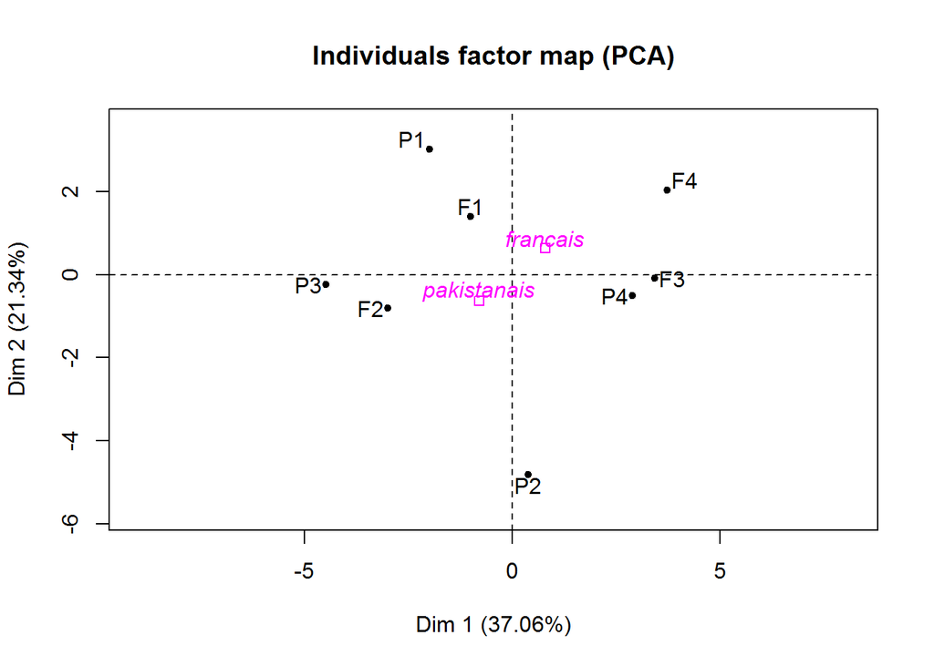

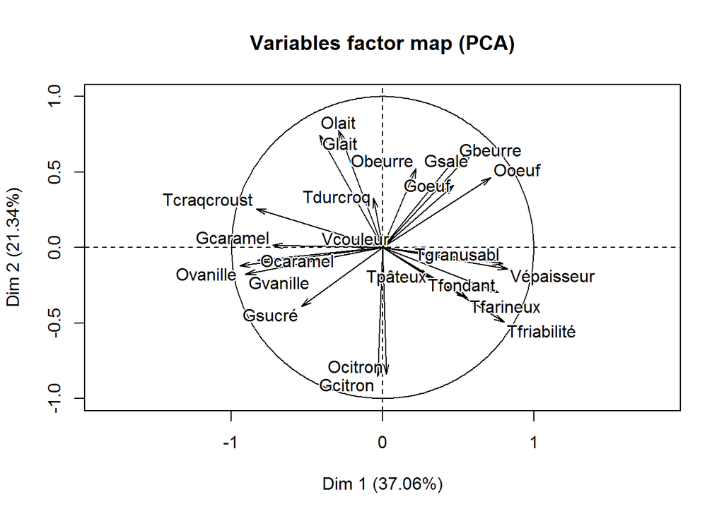

```r
x=read.table("C:/Users/user/Desktop/PFA Final/hedo_biscuit.csv",header=T,sep=";",dec=".",row.names = 1)

library(plotly)
library(doBy)
base=summaryBy(.~produit,data=data[,-c(1,2)],FUN=mean,na.rm=T,keep.names=T)
origine=c("francais","francais","francais","francais","pakistanais","pakistanais","pakistanais","pakistanais")
base=cbind.data.frame(base,origine,row.names=1)

library(FactoMineR)
library(devtools)
library(scales)
library(grid)
library("factoextra")

res=PCA(base,quali.sup = 24,graph=T,scale.unit = T)
```

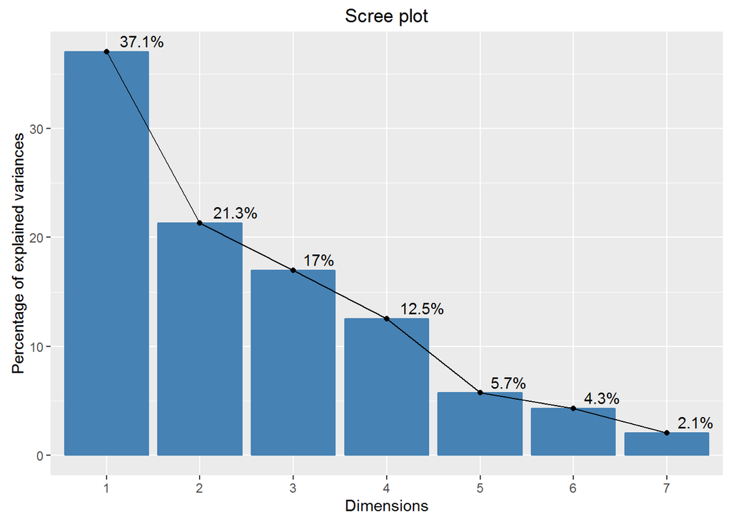

```r
fviz_screeplot(res,addlabels=TRUE,hjust = -0.3)
```

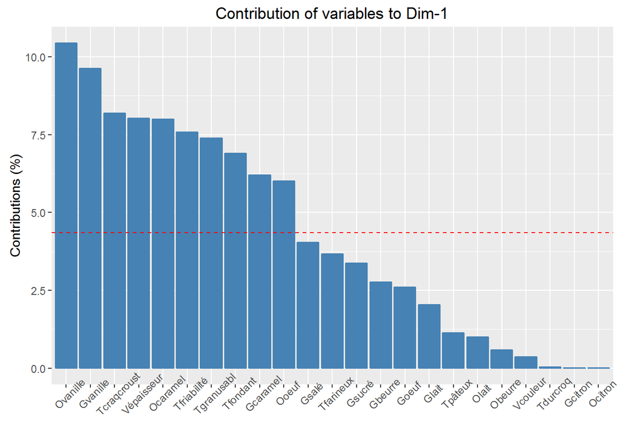

```r
fviz_contrib(res, choice="var", axes = 1 )
```

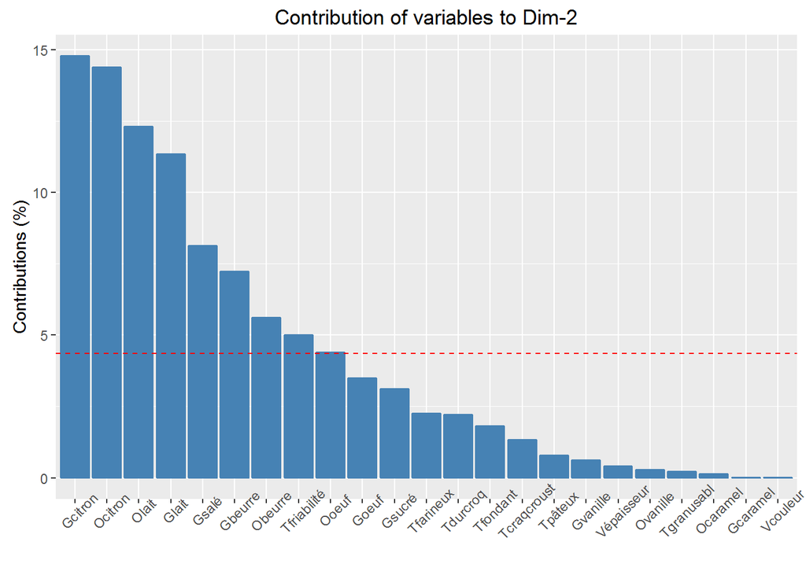

```r
fviz_contrib(res, choice="var", axes = 2 )
```

### *Cercle de corrélation:*

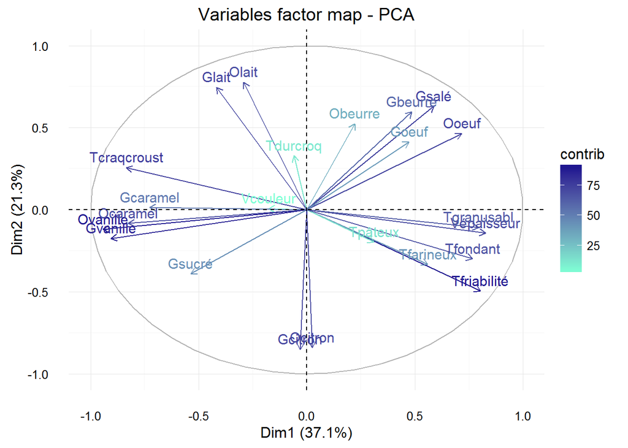

```r
fviz_pca_var(res, col.var="contrib")+
scale_color_gradient2(low="aquamarine", mid="darkblue",
      high="red", midpoint = 96) + theme_minimal()
```

### *Graph des individus:*

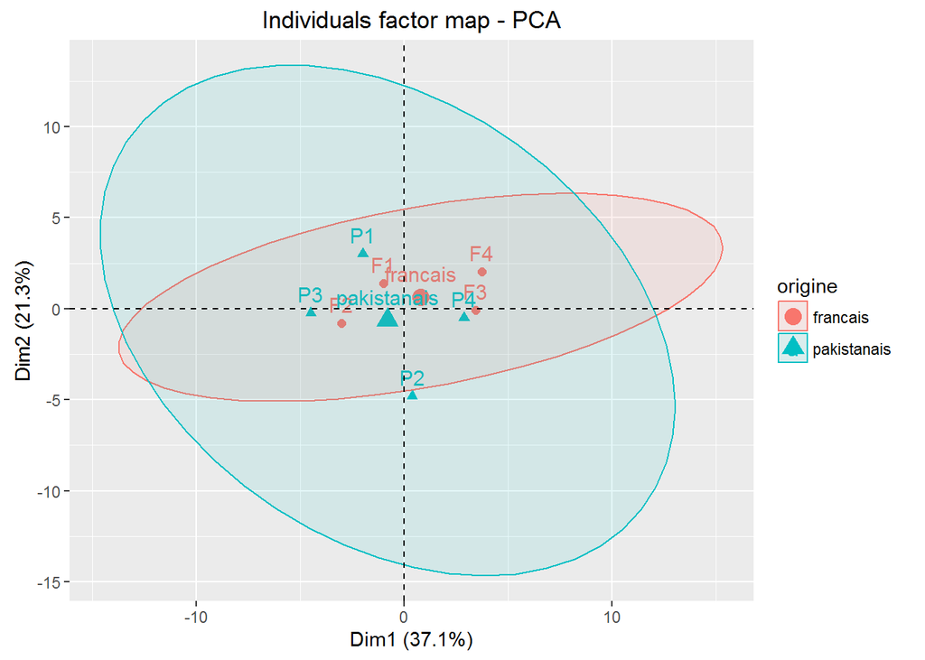

```r
fviz_pca_ind(res, habillage=24,addEllipses=T, ellipse.level=0.95)
```

### *Biplot:*

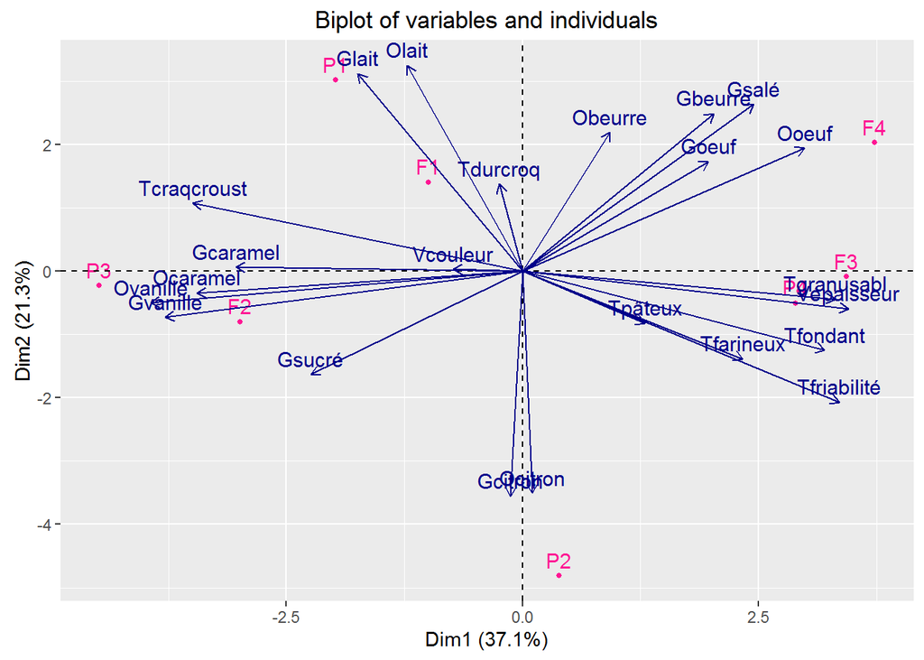

```r
fviz_pca_biplot(res, geom = c("point", "text"),col.ind = "deeppink",col.var = "darkblue",labelsize = 4, pointsize = 1)
```

## Cartographie:

### *Pour tous les consommateurs:*

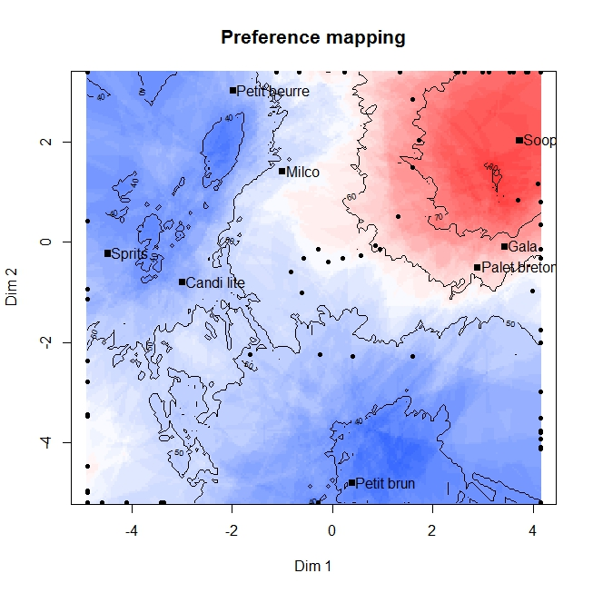